# Analysis of Hypotheses in R

This notebook includes the statistical hypothesis tests for all groups.

## Load necessary packages

```r
library(WRS2)
library(rcompanion)
library(feather)
library(ggplot2)
library(ez)
library(schoRsch)
library(MASS)
library(car)
library(ggpubr)
library(rstatix)
library(DescTools)
library(tidyverse)
library(nlme)
library(lsmeans)
library(here)
```

## Load the data

We are loading three versions of our dataframe. df_wide has one row per participant.

```r
df_wide <- read_feather(path = here('../../data_frames/results_test_18-03-2020.file'))
```

```
Coercing int64 to doubleCoercing int64 to doubleCoercing int64 to doubleCoercing int64 to doubleCoercing int64 to doubleCoercing int64 to doubleCoercing int64 to doubleCoercing int64 to doubleCoercing int64 to doubleCoercing int64 to doubleCoercing int64 to double
```

df_long has one row per trial per participant (so three rows per participant for interruption 1, 2, 3).

```r
df_long <- read_feather(path = here('../../data_frames/results_test_18-03-2020_messwdh.file'))
```

```
Coercing int64 to doubleCoercing int64 to doubleCoercing int64 to doubleCoercing int64 to double
```

df_nasa has four rows per particpant, one for each nasa-tlx test

```r
df_nasa <- read_feather(path = here('../../data_frames/results_test_18-03-2020_messwdh_nasa.file'))
```

```
Coercing int64 to doubleCoercing int64 to doubleCoercing int64 to doubleCoercing int64 to double
```

## Prepare the data

### Assign participants to the experimental group

- version 1 and 2 –> control group
- version 3 und 4 –> context-free experimental group
- version 5 und 6–> context-sensitive experimental group

```r
df_long$group <- ifelse((df_long$version == 5 | df_long$version == 6), 'context-sensitive experimental group', ifelse((df_long$version == 1 | df_long$version == 2), 'control group', 'context-free experimental group'))
df_nasa$group <- ifelse((df_nasa$version == 5 | df_nasa$version == 6), 'context-sensitive experimental group', ifelse((df_nasa$version == 1 | df_nasa$version == 2), 'control group', 'context-free experimental group'))
df_wide$group <- ifelse((df_wide$version == 5 | df_wide$version == 6), 'context-sensitive experimental group', ifelse((df_wide$version == 1 | df_wide$version == 2), 'control group', 'context-free experimental group'))
```

### Check if the design is balanced

```r
count(df_wide, group)
```

| group | n |
| --- | --- |
| context-free experimental group | 13 |
| context-sensitive experimental group | 21 |
| control group | 21 |

### Convert trial, group and subject number to factors in each dataframe

```r
df_nasa$trial <- factor(df_nasa$trial, levels=c(0,1,2,3), labels=c('0','1','2','3'))
df_nasa$group <- factor(df_nasa$group)
df_nasa$partnr <- factor(df_nasa$partnr)
df_wide$group <- factor(df_wide$group)
df_wide$partnr <- factor(df_wide$partnr)
df_long$trial <- factor(df_long$trial, levels=c(1,2,3), labels=c('1','2','3'))
df_long$group <- factor(df_long$group)
df_long$partnr <- factor(df_long$partnr)
```

## Testing Hypotheses

### Performance

None of the measures yielded any significant results, neither when outliers were excluded nor when they were not excluded. Overall, it seems that the task was very difficult for participants: They commited a lot of mistakes and achieved few right answers. Additionally, a lot of participants only worked with part of the information and ignored or missed further sources of information which could be due to information overload.

#### Correct entries

There was no significant effect for the number of correct entries. Trend: context-free group achieved on average less correct entries than the other two groups.

#### Descriptive data

```r
aggregate( correct_entries_after_interruption ~ group, df_wide, mean )
```

| group | correct_entries_after_interruption |
| --- | --- |
| context-free experimental group | 5.384615 |
| context-sensitive experimental group | 8.333333 |
| control group | 8.285714 |

```r
aggregate( correct_entries_after_interruption ~ group, df_wide, sd )
```

| group | correct_entries_after_interruption |
| --- | --- |
| context-free experimental group | 2.754949 |
| context-sensitive experimental group | 4.757450 |
| control group | 4.406165 |

##### Plot means of correct entries between groups

```r
plot_correct_entries = ggbarplot(df_wide, x = "group", y = "correct_entries_after_interruption",
          add = c("mean_se"),
          fill = c('darkgoldenrod2', 'darkcyan', 'darkred'),
          title = "Number of correct entries by group",
          xlab = "Group",
          ylab = "Number of correct entries in the order list"
          )
```

```
the condition has length > 1 and only the first element will be usedthe condition has length > 1 and only the first element will be used
```

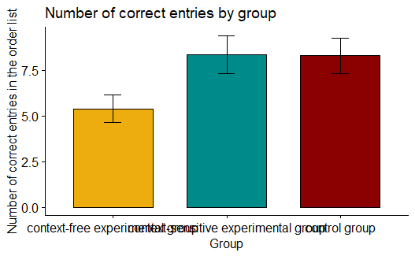

```r
plot_correct_entries
ggsave("plots_hypothesis_tests/correct_entries_per_groups.png", height = 5, width=10)
```

##### Boxplots of correct entries

```r
# boxplots
ggplot(df_wide,aes(x = group, y=correct_entries_after_interruption) ) +
  geom_boxplot() +
  stat_summary(fun.y=mean,shape=1,col='red',geom='point') +
  labs(x="group",
       y = "correct entries",
       title="correct entries by group")
```

```
`fun.y` is deprecated. Use `fun` instead.
```

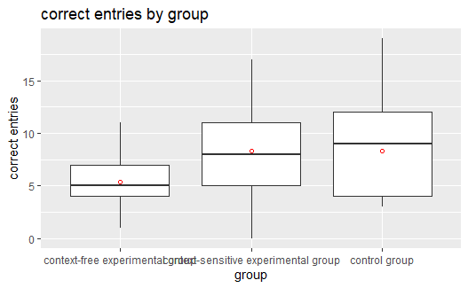

```r
ggsave("plots_hypothesis_tests/correct_entries_boxplot.png", height = 5, width=7)
```

##### Test requirements for ANOVA

- normal distribution
- variance homogenity

Set up linear model for correct_entries ~ groups

```r
lm_cor_entries <- lm(df_wide$correct_entries_after_interruption~ df_wide$group)
```

QQ-plot studentized residuals

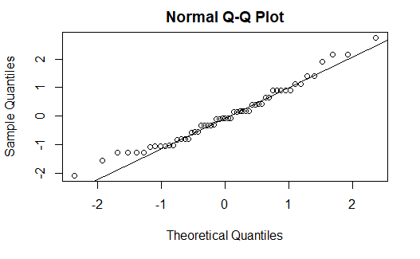

```r
rstudent_cor_entries <- rstudent(lm_cor_entries)
qqnorm(rstudent_cor_entries); qqline(rstudent_cor_entries)
```

Run Shapiro-Wilk test

```r
shapiro.test(x = rstudent_cor_entries )
```

```
    Shapiro-Wilk normality test

data:  rstudent_cor_entries
W = 0.97273, p-value = 0.2434
```

Test homogenity of variances

```r
leveneTest(df_wide$correct_entries_after_interruption~df_wide$group)
```

```
Levene's Test for Homogeneity of Variance (center = median)
      Df F value Pr(>F)
group  2  1.8087  0.174
      52
```

The tests indicate that the data is normally distributed with equal variances. Therefore, we can compute an analysis of variance.

##### ANOVA (n.s.)

Set SS to 3 because the data is unbalanced

```r
anova_correct_entries <- ezANOVA(
  data = df_wide,
  dv = correct_entries_after_interruption,
  wid = partnr,
  between = group,
  type = 3,
  detailed = TRUE,
  return_aov = TRUE)
```

```
Data is unbalanced (unequal N per group). Make sure you specified a well-considered value for the type argument to ezANOVA().Coefficient covariances computed by hccm()
```

```r
anova_out(anova_correct_entries)
```

```
$`--- ANOVA RESULTS     ------------------------------------`
       Effect      MSE df1 df2      F     p petasq getasq
1 (Intercept) 17.92364   1  52 156.90 0.000   0.75   0.75
2       group 17.92364   2  52   2.37 0.104   0.08   0.08

$`--- SPHERICITY TESTS  ------------------------------------`
[1] "N/A"

$`--- FORMATTED RESULTS ------------------------------------`
       Effect                                   Text
1 (Intercept) F(1, 52) = 156.90, p < .001, np2 = .75
2       group F(2, 52) =   2.37, p = .104, np2 = .08

$`NOTE:`
[1] "Reporting unadjusted p-values."
```

```r
summary(anova_correct_entries$aov)
```

```
            Df Sum Sq Mean Sq F value Pr(>F)
group        2     85   42.48    2.37  0.104
Residuals   52    932   17.92
```

#### Mistakes

There are no significant effects for the number of mistakes.

#### Descriptive data

```r
aggregate( mistakes_after_interruption ~ group, df_wide, mean )
```

| group | mistakes_after_interruption |
| --- | --- |
| context-free experimental group | 3.230769 |
| context-sensitive experimental group | 5.047619 |
| control group | 4.380952 |

```r
aggregate( mistakes_after_interruption ~ group, df_wide, sd )
```

| group | mistakes_after_interruption |
| --- | --- |
| context-free experimental group | 2.712743 |
| context-sensitive experimental group | 5.171810 |
| control group | 5.563058 |

##### Create boxplots of mistakes before removing outliers

```r
boxp_mistakes = ggplot(df_wide,aes(x = group, y= mistakes_after_interruption) ) +
  theme_classic() +
  geom_boxplot() +
  stat_summary(fun.y=mean,shape=1,col='red',geom='point') +
  labs(x="Group",
       y = "Incorrect order list entries",
       title="Boxplots of incorrect order list entries by group")
```

```
`fun.y` is deprecated. Use `fun` instead.
```

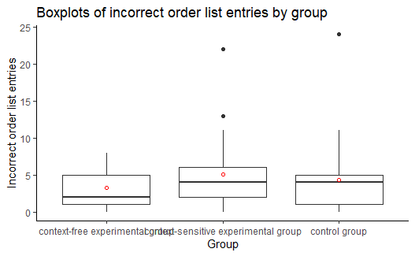

```r
print(boxp_mistakes)
ggsave("plots_hypothesis_tests/mistakes_boxplot.png", height = 5, width=7)
```

##### Plot means of mistakes (before removing outliers) between groups

Plot including error bars

```r
plot_mistakes = ggbarplot(df_wide, x = "group", y = "mistakes_after_interruption",
          add = c("mean_se"),
          fill = c('darkgoldenrod2', 'darkcyan', 'darkred'),
          title = "Number of mistakes by group",
          xlab = "Group",
          ylab = "Number of mistakes in the order list"
          )
```

```
the condition has length > 1 and only the first element will be usedthe condition has length > 1 and only the first element will be used
```

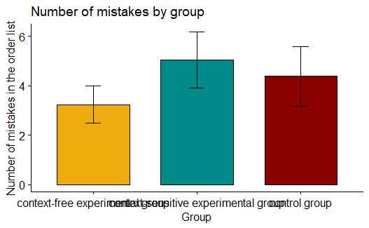

```r
plot_mistakes
```

##### Remove outliers

By re-watching the screen recordings and comparing with the experimental protocol, I analyzed what caused outliers. When looking at the number of mistakes that participants commit during the experimental task, there are two outliers (further than three standard deviations from the median): Test participants 26 and 11. The log of the order list inputs reveals that these test participants filled out all the amounts wrong (and, consequently, all the prizes). Watching the screen recording confirms that the participants never opened the document which contained the information about required amounts. Thus, both test particpants are excluded for the analysis of the mistakes.

```r
aggregate(mistakes_after_interruption ~ group, df_wide, mean)
```

| group | mistakes_after_interruption |
| --- | --- |
| context-free experimental group | 3.230769 |
| context-sensitive experimental group | 5.047619 |
| control group | 4.380952 |

```r
aggregate(mistakes_after_interruption ~ group, df_wide, sd)
```

| group | mistakes_after_interruption |
| --- | --- |
| context-free experimental group | 2.712743 |
| context-sensitive experimental group | 5.171810 |
| control group | 5.563058 |

```r
exclude <- list(11, 26)
df_perf <- subset(df_wide, !(df_wide$partnr %in% exclude))
```

##### Test requirements for ANOVA

Set up linear model for mistakes_after_interruption ~ groups

```r
lm_mistakes <- lm(df_perf$mistakes_after_interruption~ df_perf$group)
```

Get studentized residuals

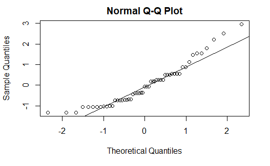

```r
rstudent_mistakes <- rstudent(lm_mistakes)
qqnorm(rstudent_mistakes); qqline(rstudent_mistakes)
```

Run Shapiro-Wilk test

```r
shapiro.test(x = rstudent_mistakes )
```

```
    Shapiro-Wilk normality test

data:  rstudent_mistakes
W = 0.92038, p-value = 0.001729
```

Test homogenity of variances

```r
leveneTest(df_perf$mistakes_after_interruption~df_perf$group)
```

```
Levene's Test for Homogeneity of Variance (center = median)
      Df F value Pr(>F)
group  2  0.4004 0.6722
      50
```

The QQplots and Shapiro-Wilk test indicate that the data is not normally distributed. Thus, we have to use the Krusal-Wallis Rank Sum Test rather than ANOVA.

##### Krusal-Wallis Rank Sum Test (n.s.)

We compute the Kruskal-Wallis Rank Sum Test after we removed the outliers.

```r
kruskaltest_mistakes <- kruskal.test(formula = mistakes_after_interruption~group,
                                     data = df_perf)
kruskaltest_mistakes
```

```
    Kruskal-Wallis rank sum test

data:  mistakes_after_interruption by group
Kruskal-Wallis chi-squared = 0.7536, df = 2, p-value =
0.6861
```

As a sensitivity analysis, we compare the test results with the data which includes the outliers.

```r
kruskaltest_mistakes_o <- kruskal.test(formula = mistakes_after_interruption~group,
                                     data = df_wide)
kruskaltest_mistakes_o
```

```
    Kruskal-Wallis rank sum test

data:  mistakes_after_interruption by group
Kruskal-Wallis chi-squared = 0.86075, df = 2, p-value =
0.6503
```

Neither test shows any significant results.

##### Plot means of mistakes (after removing outliers) between groups

Descriptive statistics

```r
aggregate(mistakes_after_interruption ~ group, df_perf, mean)
```

| group | mistakes_after_interruption |
| --- | --- |
| context-free experimental group | 3.230769 |
| context-sensitive experimental group | 4.200000 |
| control group | 3.400000 |

```r
aggregate(mistakes_after_interruption ~ group, df_perf, sd)
```

| group | mistakes_after_interruption |
| --- | --- |
| context-free experimental group | 2.712743 |
| context-sensitive experimental group | 3.503382 |
| control group | 3.362330 |

```r
plot_mistakes_o = ggbarplot(df_perf, x = "group", y = "mistakes_after_interruption",
          add = c("mean_se"),
          fill = c('darkgoldenrod2', 'darkcyan', 'darkred'),
          title = "Number of mistakes by group",
          xlab = "Group",
          ylab = "Number of mistakes in the order list"
          )
```

```
the condition has length > 1 and only the first element will be usedthe condition has length > 1 and only the first element will be used
```

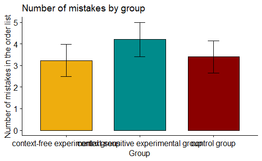

```r
plot_mistakes_o
ggsave("plots_hypothesis_tests/mistakes_per_groups.png", height = 5, width=10)
```

##### Boxplots of mistakes after removing outliers

```r
par(bg = "white")
boxplot_mistakes =
  ggplot(df_perf,aes(x = group, y= mistakes_after_interruption) ) +
  theme_classic() +
  geom_boxplot() +
  stat_summary(fun.y=mean,shape=1,col='red',geom='point') +
  labs(x="Group",
       y = "Incorrect entries per total entries",
       title="Boxplots of mistakes by group")
```

```
`fun.y` is deprecated. Use `fun` instead.
```

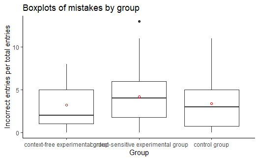

```r
print(boxplot_mistakes)
```

#### Ratio of mistakes to total amount of entries

Statistical analysis reveals no significant effect.

Compute measure

```r
df_wide <- transform(df_wide, perf = mistakes_after_interruption / entries_after_interruption)
aggregate(perf ~ group, df_wide, mean)
```

| group | perf |
| --- | --- |
| context-free experimental group | 0.3626501 |
| context-sensitive experimental group | 0.3633786 |
| control group | 0.2920626 |

```r
aggregate(perf ~ group, df_wide, sd)
```

| group | perf |
| --- | --- |
| context-free experimental group | 0.2380776 |
| context-sensitive experimental group | 0.2644656 |
| control group | 0.2684355 |

##### Boxplots of ratio of mistakes to total amount of entries

```r
par(bg = "white")
ggplot(df_wide,aes(x = group, y=perf) ) +
  geom_boxplot() +

  stat_summary(fun.y=mean,shape=1,col='red',geom='point') +
  labs(x="Group",
       y = "Incorrect entries per total entries",
       title="Boxplots of  mistakes per total entries by group")
```

```
`fun.y` is deprecated. Use `fun` instead.
```

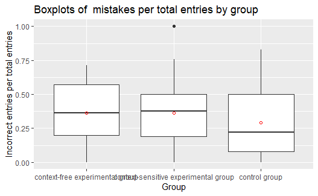

```r
ggsave("plots_hypothesis_tests/perf_boxplot.png", height = 5, width=7)
```

Plot including error bars

```r
plot_perf = ggbarplot(df_wide, x = "group", y = "perf",
          add = c("mean_se"),
          fill = c('darkgoldenrod2', 'darkcyan', 'darkred'),
          title = "Number of mistakes per total number of entries by group",
          xlab = "Group",
          ylab = "Number of mistakes per entries"
          )
```

```
the condition has length > 1 and only the first element will be usedthe condition has length > 1 and only the first element will be used
```

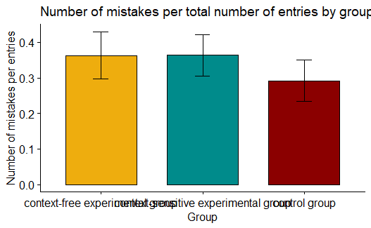

```r
plot_perf
```

##### Exclude outliers

Following the argumentation from above, the values for test participants 26 and 11 shall be removed.

```r
exclude <- list(11, 26)
df_perf <- subset(df_wide, !(df_wide$partnr %in% exclude))
aggregate(perf ~ group, df_perf, mean)
```

| group | perf |
| --- | --- |
| context-free experimental group | 0.3626501 |
| context-sensitive experimental group | 0.3436165 |
| control group | 0.2652864 |

```r
aggregate(perf ~ group, df_perf, sd)
```

| group | perf |
| --- | --- |
| context-free experimental group | 0.2380776 |
| context-sensitive experimental group | 0.2549318 |
| control group | 0.2449519 |

##### Test requirements for ANOVA

Set up lineare model for perf ~ groups

```r
lm_perf <- lm(df_perf$perf~ df_perf$group)
```

Get studentized residuals

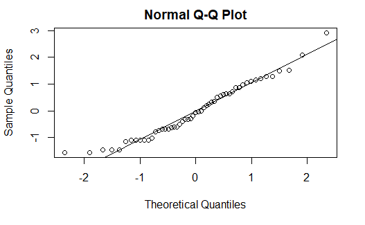

```r
rstudent_perf <- rstudent(lm_perf)
qqnorm(rstudent_perf); qqline(rstudent_perf)
```

Run Shapiro-Wilk test

```r
shapiro.test(x = rstudent_perf )
```

```
    Shapiro-Wilk normality test

data:  rstudent_perf
W = 0.96207, p-value = 0.09065
```

Test homogenity of variances

```r
leveneTest(perf~group,  data = df_perf)
```

```
Levene's Test for Homogeneity of Variance (center = median)
      Df F value Pr(>F)
group  2  0.0329 0.9677
      50
```

##### Krusal-Wallis Rank Sum Test (n.s.)

We compute the Kruskal-Wallis Rank Sum Test after we removed the outliers.

```r
kruskaltest_perf <-kruskal.test(df_perf$perf~ df_perf$group)
kruskaltest_perf
```

```
    Kruskal-Wallis rank sum test

data:  df_perf$perf by df_perf$group
Kruskal-Wallis chi-squared = 1.6045, df = 2, p-value =
0.4483
```

As a sensitivity analysis, we compare the test results with the data which includes the outliers.

```r
kruskaltest_perf_o <-kruskal.test(df_wide$perf~ df_wide$group)
kruskaltest_perf_o
```

```
    Kruskal-Wallis rank sum test

data:  df_wide$perf by df_wide$group
Kruskal-Wallis chi-squared = 1.0823, df = 2, p-value =
0.5821
```

Both tests show no significant results.

##### Plot means of ratio of mistakes to all entries between groups (after removing outliers)

Descriptive analysis

```r
mean_perf <- tapply(df_perf$perf, df_perf$group, mean)
tapply(df_perf$perf, df_perf$group, sd)
```

```
     context-free experimental group
                           0.2380776
context-sensitive experimental group
                           0.2549318
                       control group
                           0.2449519
```

```r
plot_perf_o = ggbarplot(df_perf, x = "group", y = "perf",
          add = c("mean_se"),
          fill = c('darkgoldenrod2', 'darkcyan', 'darkred'),
          title = "Number of mistakes per total number of entries by group",
          xlab = "Group",
          ylab = "Number of mistakes per entries"
          )
```

```
the condition has length > 1 and only the first element will be usedthe condition has length > 1 and only the first element will be used
```

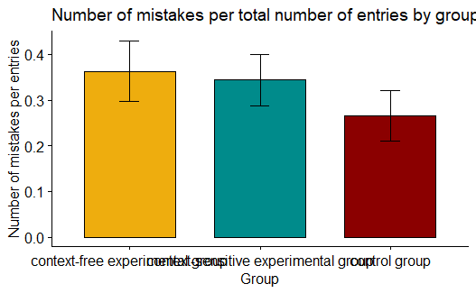

```r
plot_perf_o
ggsave("plots_hypothesis_tests/perf_per_groups.png", height = 5, width=10)
```

### NASA-TLX

Does mental workload when working on the primary task differ between groups and over time?

##### Check requirements for ANOVA

Compute ezANOVA to extract residuals using SS = 3 because the data is unbalanced

```r
ez_nasa_anova = ezANOVA(
data = df_nasa
, dv = NASATLX
, wid = partnr
, within = trial
, between = group
, detailed = TRUE
, type = 3
, return_aov = TRUE
)
```

```
Data is unbalanced (unequal N per group). Make sure you specified a well-considered value for the type argument to ezANOVA().
```

```r
anova_out(ez_nasa_anova)
```

```
$`--- ANOVA RESULTS     ------------------------------------`
       Effect       MSE df1 df2       F     p petasq getasq
1 (Intercept) 3.4247812   1  52 1144.41 0.000   0.96   0.95
2       group 3.4247812   2  52    0.71 0.494   0.03   0.02
3       trial 0.2743698   3 156   10.53 0.000   0.17   0.04
4 group:trial 0.2743698   6 156    0.92 0.482   0.03   0.01

$`--- SPHERICITY TESTS  ------------------------------------`
       Effect p_Mauchly GGEpsilon  p_GG HFEpsilon  p_HF
1       trial     0.000     0.766 0.000     0.803 0.000
2 group:trial     0.000     0.766 0.465     0.803 0.468

$`--- FORMATTED RESULTS ------------------------------------`
       Effect                                     Text
1 (Intercept)  F(1, 52) = 1144.41, p < .001, np2 = .96
2       group  F(2, 52) =    0.71, p = .494, np2 = .03
3       trial F(3, 156) =   10.53, p < .001, np2 = .17
4 group:trial F(6, 156) =    0.92, p = .465, np2 = .03

$`NOTE:`
[1] "p-values for the following effects were GG-adjusted (p_Mauchly <= 0.05): trial; group:trial. Reporting uncorrected degrees of freedom."
```

Check normal distribution assumption by plotting residuals

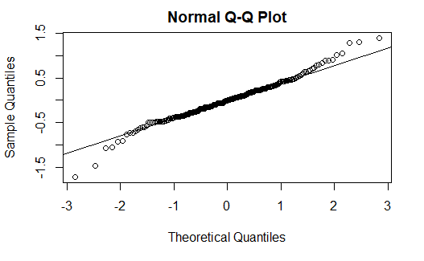

```r
aov_nasa.pr <- proj(ez_nasa_anova$aov)
nasa_res <- aov_nasa.pr[[3]][, "Residuals"]
qqnorm(nasa_res); qqline(nasa_res)
```

Run Shapiro-Wilk test

```r
shapiro.test(x = nasa_res )
```

```
    Shapiro-Wilk normality test

data:  nasa_res
W = 0.98018, p-value = 0.003486
```

Run Levene test for homogeneity of variance across groups (n.s.)

```r
leveneTest(df_nasa$NASATLX~df_nasa$group)
```

```
Levene's Test for Homogeneity of Variance (center = median)
       Df F value Pr(>F)
group   2  0.3812 0.6835
      217
```

QQplot of the residuals indicates that the assumption of normal distribution is not met. Therefore, we compute robust ANOVA.

##### Compute robust ANOVA

significant main effect of trial

```r
bwtrim(formula = NASATLX ~ group * trial, id = partnr, data = df_nasa)
```

```
Call:
bwtrim(formula = NASATLX ~ group * trial, id = partnr, data = df_nasa)
```

|  | value | df1 | df2 | p.value |
| --- | --- | --- | --- | --- |
| group | 0.9505 | 2 | 15.9282 | 0.4074 |
| trial | 6.7891 | 3 | 19.3339 | 0.0026 |
| group:trial | 2.6245 | 6 | 15.8877 | 0.0579 |

```
NA
```

##### Plot interaction

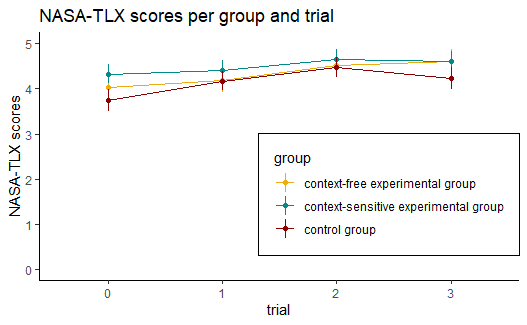

```r
df_nasa %>%
  group_by(trial,group) %>%
  summarise(nasa_groups = mean(NASATLX),
            nasa_sem = (sd(NASATLX)/sqrt(length(NASATLX)))) -> nasa2
nasa2 %>%
  ggplot() +
  theme_classic() +
  aes(x = trial, y = nasa_groups, colour = group) +
  geom_line(aes(group = group)) +
  scale_color_manual(values =  c('darkgoldenrod2', 'darkcyan', 'darkred')) +
  geom_point() +
  geom_linerange(aes(x = trial, ymin = nasa_groups - nasa_sem, ymax = nasa_groups + nasa_sem), size = .3) +
  labs(title = "NASA-TLX scores per group and trial", y = "NASA-TLX scores") +
  theme(legend.justification=c(1,0), legend.position=c(1,0.1), legend.box.background = element_rect(),
  legend.box.margin = margin(6, 6, 6, 6)) +
  scale_y_continuous(limits = c(0,5))

ggsave("plots_hypothesis_tests/nasa-tlx_interaction_plot.png")
```

##### Plot main effect of trial

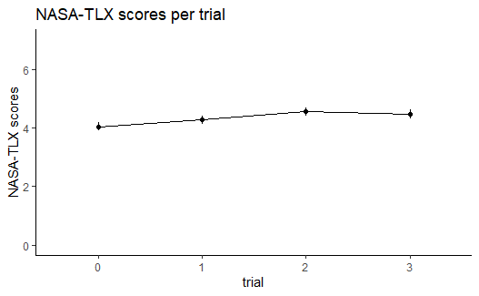

```r
df_nasa %>%
  group_by(trial) %>%
  summarise(nasa_groups = mean(NASATLX),
            nasa_sem = (sd(NASATLX)/sqrt(length(NASATLX)))) -> nasa3
nasa3 %>%
  ggplot() +
  theme_classic() +
  aes(x = trial, y = nasa_groups) +
  geom_line(group = 1) +
  geom_smooth() +
  geom_point() +
  geom_linerange(aes(x = trial, ymin = nasa_groups - nasa_sem, ymax = nasa_groups + nasa_sem), size = .3) +
  labs(title = "NASA-TLX scores per trial", y = "NASA-TLX scores") +
  scale_y_continuous(limits = c(0,7))
ggsave("plots_hypothesis_tests/nasa-tlx_main_effect.png")
```

##### Boxplots

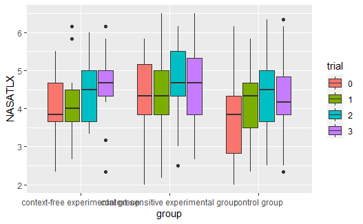

```r
ggplot(aes(y = NASATLX, x = group, fill = trial), data = df_nasa) + geom_boxplot()
```

##### Compute post-hoc tests

###### Test effect of trial

Computing pairwise comparisons between all groups using Wilcoxon signed-rank test shows that NASA-TLX scores after trial 0 (before the interruptions) are significantly lower than after trial 2 and 3 (after the second/third interruption). Also, NASA-TLX scores after trial 1 are significantly lower than after trial 2.

```r
pwc_trial <- df_nasa %>%
  wilcox_test(NASATLX ~ trial,
              comparisons = list(c(0, 1), c(0,2), c(0,3), c(1,2), c(2,3)),
              paired = TRUE,
              p.adjust.method = "holm")
pwc_trial
```

|  | .y. | group1 | group2 | n1 | n2 | statistic | p | p.adj | p.adj.signif |
| --- | --- | --- | --- | --- | --- | --- | --- | --- | --- |
| 1 | NASATLX | 0 | 1 | 55 | 55 | 446.5 | 0.043000 | 0.085000 | ns |
| 2 | NASATLX | 0 | 2 | 55 | 55 | 278.0 | 0.000311 | 0.001000 | ** |
| 3 | NASATLX | 0 | 3 | 55 | 55 | 346.5 | 0.001000 | 0.003000 | ** |
| 4 | NASATLX | 1 | 2 | 55 | 55 | 274.0 | 0.000157 | 0.000785 | *** |
| 5 | NASATLX | 2 | 3 | 55 | 55 | 644.5 | 0.396000 | 0.396000 | ns |

Pairwise comparisons between trials just for the control group between measurepoints one and two, one and three, two and three and three and four indicate that there is a significant difference between the first point of measurement and the third one (p = .034).

```r
df_control <- df_nasa[df_nasa$group == "control group",]
pwc_trial_control <- df_control %>%
  wilcox_test(NASATLX ~ trial,
              comparisons = list(c(0, 1), c(0,2), c(1,2), c(2,3)),
              paired = TRUE,
              p.adjust.method = "holm")
pwc_trial_control
```

|  | .y. | group1 | group2 | n1 | n2 | statistic | p | p.adj | p.adj.signif |
| --- | --- | --- | --- | --- | --- | --- | --- | --- | --- |
| 1 | NASATLX | 0 | 1 | 21 | 21 | 40.0 | 0.028 | 0.065 | ns |
| 2 | NASATLX | 0 | 2 | 21 | 21 | 34.0 | 0.008 | 0.034 | * |
| 3 | NASATLX | 1 | 2 | 21 | 21 | 49.0 | 0.022 | 0.065 | ns |
| 4 | NASATLX | 2 | 3 | 21 | 21 | 146.5 | 0.040 | 0.065 | ns |

Pairwise comparisons between trials just for the context-free experimental group do not reach statistical significance.

```r
df_exp1 <- df_nasa[df_nasa$group == "context-free experimental group",]
pwc_trial_exp1 <- df_exp1 %>%
  wilcox_test(NASATLX ~ trial,
              comparisons = list(c(0, 1), c(0,2), c(1,2), c(1,3), c(0,3)),
              paired = TRUE,
              p.adjust.method = "holm")
pwc_trial_exp1
```

|  | .y. | group1 | group2 | n1 | n2 | statistic | p | p.adj | p.adj.signif |
| --- | --- | --- | --- | --- | --- | --- | --- | --- | --- |
| 1 | NASATLX | 0 | 1 | 13 | 13 | 32.5 | 0.380 | 0.380 | ns |
| 2 | NASATLX | 0 | 2 | 13 | 13 | 17.0 | 0.050 | 0.132 | ns |
| 3 | NASATLX | 1 | 2 | 13 | 13 | 14.5 | 0.033 | 0.132 | ns |
| 4 | NASATLX | 1 | 3 | 13 | 13 | 9.0 | 0.035 | 0.132 | ns |
| 5 | NASATLX | 0 | 3 | 13 | 13 | 5.0 | 0.014 | 0.072 | ns |

Pairwise comparisons between trials just for the context-sensitive experimental group do not reach statistical significance.

```r
df_exp2 <- df_nasa[df_nasa$group == "context-sensitive experimental group",]
pwc_trial_exp2 <- df_exp2 %>%
  wilcox_test(NASATLX ~ trial,
              comparisons = list(c(0,1), c(0,2), c(1,2)),
              paired = TRUE, p.adjust.method = "holm")
pwc_trial_exp2
```

|  | .y. | group1 | group2 | n1 | n2 | statistic | p | p.adj | p.adj.signif |
| --- | --- | --- | --- | --- | --- | --- | --- | --- | --- |
| 1 | NASATLX | 0 | 1 | 21 | 21 | 81.5 | 0.601 | 0.601 | ns |
| 2 | NASATLX | 0 | 2 | 21 | 21 | 51.0 | 0.138 | 0.276 | ns |
| 3 | NASATLX | 1 | 2 | 21 | 21 | 38.5 | 0.042 | 0.127 | ns |

###### Comparing control group and experimental group context-sensitive at trial 0

Control group has significantly lower values for workload before the interruptions (p = .026).

```r
control_vs_exp_context_trial0 <- wilcox.test( df_wide[(df_wide$group == "context-sensitive experimental group"),]$NASATLX_1, df_wide[(df_wide$group == "control group"),]$NASATLX_1, alternative = 'g')
```

```
kann bei Bindungen keinen exakten p-Wert Berechnen
```

```r
control_vs_exp_context_trial0
```

```
    Wilcoxon rank sum test with continuity correction

data:  df_wide[(df_wide$group == "context-sensitive experimental group"),  and df_wide[(df_wide$group == "control group"), ]$NASATLX_1    ]$NASATLX_1 and df_wide[(df_wide$group == "control group"), ]$NASATLX_1
W = 298, p-value = 0.02614
alternative hypothesis: true location shift is greater than 0
```

###### Comparing control group and experimental group context-sensitive at trial 4 (n.s.)

```r
 wilcox.test( df_wide[(df_wide$group == "context-sensitive experimental group"),]$NASATLX_4, df_wide[(df_wide$group == "control group"),]$NASATLX_4, alternative = 'g')
```

```
kann bei Bindungen keinen exakten p-Wert Berechnen
```

```
    Wilcoxon rank sum test with continuity correction

data:  df_wide[(df_wide$group == "context-sensitive experimental group"),  and df_wide[(df_wide$group == "control group"), ]$NASATLX_4    ]$NASATLX_4 and df_wide[(df_wide$group == "control group"), ]$NASATLX_4
W = 267.5, p-value = 0.1207
alternative hypothesis: true location shift is greater than 0
```

##### Comparing only the mental workload after interruptions (signifiant effect of trial, no significant effect of interaction or group)

Create df with data only after the first interruption.

```r
df_nasa123 <- df_nasa[!(df_nasa$trial == 0),]
df_nasa123$trial <- factor(df_nasa123$trial)
```

Compute robust ANOVA

```r
bwtrim(formula = NASATLX ~ group * trial, id = partnr, data = df_nasa123)
```

```
Call:
bwtrim(formula = NASATLX ~ group * trial, id = partnr, data = df_nasa123)
```

|  | value | df1 | df2 | p.value |
| --- | --- | --- | --- | --- |
| group | 0.4820 | 2 | 15.9154 | 0.6263 |
| trial | 9.1435 | 2 | 20.5698 | 0.0014 |
| group:trial | 2.7695 | 4 | 15.8359 | 0.0639 |

```
NA
```

Plot the interaction for NASA-TLX values after the first interruption

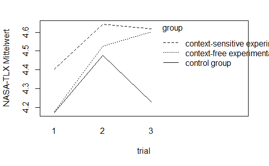

```r
interaction.plot(df_nasa123$`trial`, df_nasa123$group, df_nasa123$NASATLX, xlab = 'trial', ylab = 'NASA-TLX Mittelwert', trace.label = 'group', cex=1.3, pch=1, pt.cex = 1)
```

##### Comparing NASA-TLX group differences without the context-free experimental group (to check for effects of the unbalanced data)

As when the whole data set is used, the analysis yields a significant main effect of trial (p= .031) but no significant effects of trial or group.

Compute df without context-free experimental group

```r
df_exp_control <- df_nasa[!(df_nasa$group=="context-free experimental group"),]
df_exp_control$trial <- factor(df_exp_control$trial, levels=c(0,1,2,3), labels=c('0','1','2','3'))
df_exp_control$group <- factor(df_exp_control$group)
df_exp_control$partnr <- factor(df_exp_control$partnr)
```

Compute robust ANOVA

```r
bwtrim(formula = NASATLX ~ group * trial, id = partnr, data = df_exp_control)
```

```
Call:
bwtrim(formula = NASATLX ~ group * trial, id = partnr, data = df_exp_control)
```

|  | value | df1 | df2 | p.value |
| --- | --- | --- | --- | --- |
| group | 1.9786 | 1 | 23.3669 | 0.1727 |
| trial | 3.6498 | 3 | 19.5285 | 0.0306 |
| group:trial | 1.5626 | 3 | 19.5285 | 0.2303 |

```
NA
```

Compute pairwise comparisons

```r
pwc_trial <- df_exp_control %>%
  wilcox_test(NASATLX ~ trial, paired = TRUE, p.adjust.method = "bonferroni")
pwc_trial
```

|  | .y. | group1 | group2 | n1 | n2 | statistic | p | p.adj | p.adj.signif |
| --- | --- | --- | --- | --- | --- | --- | --- | --- | --- |
| 1 | NASATLX | 0 | 1 | 42 | 42 | 247.5 | 0.075 | 0.452 | ns |
| 2 | NASATLX | 0 | 2 | 42 | 42 | 163.5 | 0.003 | 0.016 | * |
| 3 | NASATLX | 0 | 3 | 42 | 42 | 276.5 | 0.029 | 0.174 | ns |
| 4 | NASATLX | 1 | 2 | 42 | 42 | 164.0 | 0.002 | 0.010 | ** |
| 5 | NASATLX | 1 | 3 | 42 | 42 | 312.0 | 0.189 | 1.000 | ns |
| 6 | NASATLX | 2 | 3 | 42 | 42 | 410.0 | 0.228 | 1.000 | ns |

#### Subscales

Subscales for effort, mental demand and performance did not reach statistical significance (see file “nasa_subscales_anaylsis.Rmd” for a more detailed analysis).

##### Frustration: significant main effect of trial (F(3, 156) = 8.34, p < .001, np2 = .14)

QQplots and levenetest indicate normal distribution and variance homogenity.

```r
nasa_frustration_anova <- ezANOVA(
  data = df_nasa,
  dv = nasa_tlx_frustration,
  wid = partnr,
  within = trial,
  between = group,
  detailed = TRUE,
  return_aov = TRUE,
  type = 3
)
```

```
Data is unbalanced (unequal N per group). Make sure you specified a well-considered value for the type argument to ezANOVA().
```

```r
anova_out(nasa_frustration_anova)
```

```
$`--- ANOVA RESULTS     ------------------------------------`
       Effect      MSE df1 df2      F     p petasq getasq
1 (Intercept) 8.193223   1  52 508.65 0.000   0.91   0.87
2       group 8.193223   2  52   0.97 0.386   0.04   0.03
3       trial 1.098079   3 156   8.34 0.000   0.14   0.04
4 group:trial 1.098079   6 156   1.54 0.169   0.06   0.02

$`--- SPHERICITY TESTS  ------------------------------------`
       Effect p_Mauchly GGEpsilon  p_GG HFEpsilon  p_HF
1       trial     0.000     0.808 0.000     0.850 0.000
2 group:trial     0.000     0.808 0.184     0.850 0.180

$`--- FORMATTED RESULTS ------------------------------------`
       Effect                                    Text
1 (Intercept)  F(1, 52) = 508.65, p < .001, np2 = .91
2       group  F(2, 52) =   0.97, p = .386, np2 = .04
3       trial F(3, 156) =   8.34, p < .001, np2 = .14
4 group:trial F(6, 156) =   1.54, p = .184, np2 = .06

$`NOTE:`
[1] "p-values for the following effects were GG-adjusted (p_Mauchly <= 0.05): trial; group:trial. Reporting uncorrected degrees of freedom."
```

Plot interaction

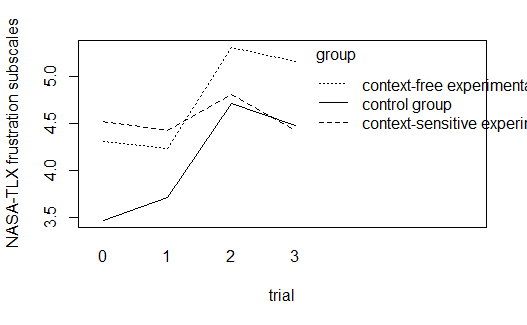

```r
interaction.plot(df_nasa$`trial`, df_nasa$group, df_nasa$nasa_tlx_frustration, xlab = 'trial', ylab = 'NASA-TLX frustration subscales', trace.label = 'group', cex=1.3, pch=1, pt.cex = 1)
```

##### Physical demand: significant main effect of trial

QQplot of the residuals indicates that the assumption of normal distribution is not met –> compute robust ANOVA.

```r
bwtrim(formula = nasa_tlx_physical_demand ~ group * trial, id = partnr, data = df_nasa)
```

```
Call:
bwtrim(formula = nasa_tlx_physical_demand ~ group * trial, id = partnr,
    data = df_nasa)
```

|  | value | df1 | df2 | p.value |
| --- | --- | --- | --- | --- |
| group | 1.0795 | 2 | 15.6595 | 0.3638 |
| trial | 4.6226 | 3 | 17.1491 | 0.0152 |
| group:trial | 0.4005 | 6 | 15.2717 | 0.8675 |

```
NA
```

Plot interaction

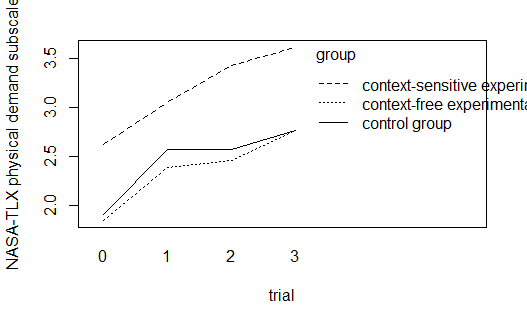

```r
interaction.plot(df_nasa$`trial`, df_nasa$group, df_nasa$nasa_tlx_physical_demand, xlab = 'trial', ylab = 'NASA-TLX physical demand subscale', trace.label = 'group', cex=1.3, pch=1, pt.cex = 1)
```

##### Time: significant main effect of trial

The Levene test for homogenity of variances indicates that variance homogenity is not given, so we compute robust ANOVA.

```r
bwtrim(formula = nasa_tlx_time ~ group * trial, id = partnr, data = df_nasa)
```

```
Call:
bwtrim(formula = nasa_tlx_time ~ group * trial, id = partnr,
    data = df_nasa)
```

|  | value | df1 | df2 | p.value |
| --- | --- | --- | --- | --- |
| group | 0.5062 | 2 | 14.7704 | 0.6129 |
| trial | 6.6508 | 3 | 18.4806 | 0.0031 |
| group:trial | 0.8242 | 6 | 15.7114 | 0.5679 |

```
NA
```

Plot interaction

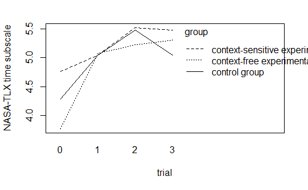

```r
interaction.plot(df_nasa$`trial`, df_nasa$group, df_nasa$nasa_tlx_time, xlab = 'trial', ylab = 'NASA-TLX time subscale', trace.label = 'group', cex=1.3, pch=1, pt.cex = 1)
```

### Resumption lags

##### For a more detailed analysis of resumption, list input and purposeful action lags, including all transformations, see the file “res_lags.Rmd”.

resumption lag = time from the moment that the order list is opened in the browser (after the interruption) until the moment when test participants press a key or do a mouse click (in ms). We analyse absolute time and time relative to the average inter-click intervals, measured during the last two minutes of the primary task (minus / divided by the average time).

Analysing distribution characteristics for raw, log-transformed and inverted resumption lags indicate that resumption speed (1/resumption lags) has the best distribution characteristics and shall therefore be used for the subsequent analysis. The analysis revealed significant main effects of group and trial.

#### Test normal distribution assumptions for 1/resumption lags (speed)

transform the data

```r
df_long$res_speed <- 1/df_long$resumption_lags
```

```r
res_speed_anova <- aov(res_speed ~ trial*group + Error(partnr/(trial)), data=df_long)
summary(res_speed_anova)
```

```
Error: partnr
          Df    Sum Sq   Mean Sq F value Pr(>F)
group      2 3.816e-08 1.908e-08   3.205 0.0487 *
Residuals 52 3.096e-07 5.954e-09
---
Signif. codes:  0 ‘***’ 0.001 ‘**’ 0.01 ‘*’ 0.05 ‘.’ 0.1 ‘ ’ 1

Error: partnr:trial
             Df    Sum Sq  Mean Sq F value  Pr(>F)
trial         2 6.520e-08 3.26e-08   7.186 0.00119 **
trial:group   4 7.200e-09 1.81e-09   0.399 0.80890
Residuals   104 4.717e-07 4.54e-09
---
Signif. codes:  0 ‘***’ 0.001 ‘**’ 0.01 ‘*’ 0.05 ‘.’ 0.1 ‘ ’ 1
```

```r
aov_res_speed <- ezANOVA(
  data = df_long
  , dv = res_speed
  , wid = partnr
  , within = trial
  , between = group
  , detailed = TRUE
  , return_aov = TRUE
  , type = 3
)
```

```
Data is unbalanced (unequal N per group). Make sure you specified a well-considered value for the type argument to ezANOVA().
```

```r
anova_out(aov_res_speed)
```

```
$`--- ANOVA RESULTS     ------------------------------------`
       Effect          MSE df1 df2      F     p petasq getasq
1 (Intercept) 5.953618e-09   1  52 541.90 0.000   0.91   0.81
2       group 5.953618e-09   2  52   3.20 0.049   0.11   0.05
3       trial 4.535987e-09   2 104   6.14 0.003   0.11   0.07
4 group:trial 4.535987e-09   4 104   0.40 0.809   0.02   0.01

$`--- SPHERICITY TESTS  ------------------------------------`
       Effect p_Mauchly GGEpsilon  p_GG HFEpsilon  p_HF
1       trial     0.099     0.920 0.004     0.952 0.004
2 group:trial     0.099     0.920 0.793     0.952 0.800

$`--- FORMATTED RESULTS ------------------------------------`
       Effect                                    Text
1 (Intercept)  F(1, 52) = 541.90, p < .001, np2 = .91
2       group  F(2, 52) =   3.20, p = .049, np2 = .11
3       trial F(2, 104) =   6.14, p = .003, np2 = .11
4 group:trial F(4, 104) =   0.40, p = .809, np2 = .02

$`NOTE:`
[1] "No adjustments necessary (all p_Mauchly > 0.05)."
```

Check normal distribution assumption by plotting residuals

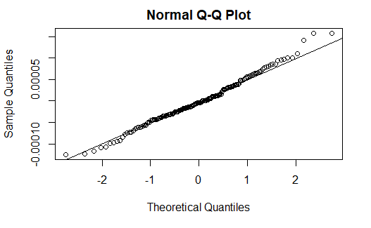

```r
aov_res_speed.pr <- proj(res_speed_anova)
reslagspeed_res <- aov_res_speed.pr[[3]][, "Residuals"]
qqnorm(reslagspeed_res); qqline(reslagspeed_res)
```

Run Shapiro-Wilk test

```r
shapiro.test(x = reslagspeed_res )
```

```
    Shapiro-Wilk normality test

data:  reslagspeed_res
W = 0.98909, p-value = 0.2326
```

Run Levene test for homogenity of variance across groups

```r
leveneTest(df_long$res_speed~df_long$group)
```

```
Levene's Test for Homogeneity of Variance (center = median)
       Df F value Pr(>F)
group   2  1.1421 0.3217
      162
```

QQplot of the residuals indicates that the assumption of normal distribution and variance homogenity are met.  
Resumption speed meets the assumptions for ANOVA best.

```
`fun.y` is deprecated. Use `fun` instead.
```

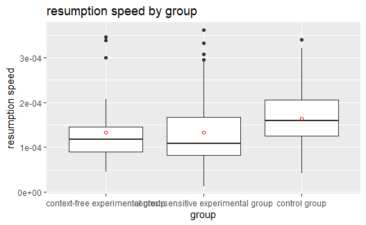

```r
# Boxplot for resumption speed per group
ggplot(df_long,aes(x = group, y=res_speed) ) +
  geom_boxplot() +
  stat_summary(fun.y=mean,shape=1,col='red',geom='point') +
  labs(x="group",
       y = "resumption speed",
       title="resumption speed by group")
```

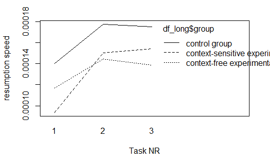

```r
# interaction plot
interaction.plot(df_long$trial, df_long$group, df_long$res_speed, xlab = 'Task NR', ylab = 'resumption speed')
```

```r
df_long %>%
  group_by(trial,group) %>%
  summarise(res_speed_groups = mean(res_speed),
            res_speed_sem = (sd(res_speed)/sqrt(length(res_speed)))) -> df_rs
df_rs %>%
  ggplot() +
  theme_classic() +
  aes(x = trial, y = res_speed_groups, colour = group) +
  geom_line(aes(group = group)) +
  scale_color_manual(values =  c('darkgoldenrod2', 'darkcyan', 'darkred')) +
  geom_point() +
  geom_linerange(aes(x = trial, ymin = res_speed_groups - res_speed_sem, ymax = res_speed_groups + res_speed_sem), size = .3) +
  theme(legend.box.background = element_rect(),
  legend.box.margin = margin(4, 4, 4, 4)) +
  labs(title = "Resumption speed per group and trial", y = "Resumption speed in 1/ms")
  scale_y_continuous(limits = c(0,0.0003))
```

```
<ScaleContinuousPosition>
 Range:
 Limits:    0 -- 0.0003
```

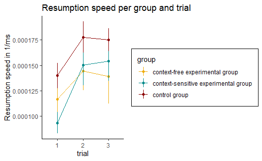

```r
ggsave("plots_hypothesis_tests/res_speed_per_groups.png")
```

#### Post-hoc analysis

Pairwise t-tests for trials

```r
pwc_trial <- df_long%>%
  pairwise_t_test(
    res_speed ~ trial, paired = TRUE,
    p.adjust.method = "holm"
    )
pwc_trial
```

|  | .y. | group1 | group2 | n1 | n2 | statistic | df | p | p.adj | p.adj.signif |
| --- | --- | --- | --- | --- | --- | --- | --- | --- | --- | --- |
| 1 | res_speed | 1 | 2 | 55 | 55 | -3.93831563 | 54 | 0.000237 | 0.000711 | *** |
| 2 | res_speed | 1 | 3 | 55 | 55 | -3.17008002 | 54 | 0.003000 | 0.005000 | ** |
| 3 | res_speed | 2 | 3 | 55 | 55 | 0.05751075 | 54 | 0.954000 | 0.954000 | ns |

Pairwise t-tests indicte significant differences between trials one and two / three.

#### Compute contrasts between control group and both experimental groups / only the context-sensitive experimental group after setting up a mixed linear model

The contrast between control group and both experimental groups reaches statistical significance. The other contrast does not.

```r
lm.res_lags <- lme(res_speed ~ group*trial, data = df_long, random = ~1|partnr, correlation = corCompSymm(form = ~1|partnr))
leastsquare = lsmeans(lm.res_lags, "group")
```

```
NOTE: Results may be misleading due to involvement in interactions
```

```r
Contrasts = list(ControlvsExp = c(-1, -1, 2),
                 ControlvsExpContext = c(0, -1, 1))
contrast(leastsquare, Contrasts, adjust="sidak")
```

```
 contrast            estimate       SE df t.ratio p.value
 ControlvsExp        6.24e-05 2.50e-05 52 2.498   0.0312
 ControlvsExpContext 3.15e-05 1.37e-05 52 2.294   0.0511

Results are averaged over the levels of: trial
Degrees-of-freedom method: containment
P value adjustment: sidak method for 2 tests
```

### List input lags

Compare how long it takes test participants to make the next order list entry in the order list after an interruption. Untransformed list input lags meet the requirements for ANOVA best and shall therefore be used for analysis. There is a significant main effect of trial but no further significant effects.

##### Replace missing values with median

```r
aggregate(df_long$list_input_lags, by= list(df_long$group),FUN=function(x) {sum(is.na(x))} )
```

| Group.1 | x |
| --- | --- |
| context-free experimental group | 4 |
| context-sensitive experimental group | 7 |
| control group | 6 |

Missing values per test participant

```r
aggregate(df_long$list_input_lags, by= list(df_long$partnr),FUN=function(x) {sum(is.na(x))} )
```

| Group.1 | x |
| --- | --- |
| 1 | 0 |
| 3 | 0 |
| 4 | 1 |
| 6 | 0 |
| 7 | 0 |
| 8 | 1 |
| 9 | 0 |
| 11 | 0 |
| 12 | 0 |
| 13 | 0 |

[output cut: 45 more lines]

Substitute missing values with median

```r
df_list_md <- df_long  %>% select(partnr, trial, group,list_input_lags)
list_exp <- df_list_md$list_input_lags[which(df_list_md$group == "context-sensitive experimental group")]
list_control <- df_list_md$list_input_lags[which(df_list_md$group == "control group")]
list_exp_2 <- df_list_md$list_input_lags[which(df_list_md$group == "context-free experimental group")]
md_exp <- median(list_exp, na.rm = TRUE)
md_control <- median(list_control, na.rm = TRUE)
md_exp_2 <- median(list_exp_2, na.rm = TRUE)
# replace NA's with median
df_list_md$list_input_lags[is.na(df_list_md$list_input_lags) & df_list_md$group == "context-sensitive experimental group"] <- md_exp
df_list_md$list_input_lags[is.na(df_list_md$list_input_lags) & df_list_md$group == "control group"] <- md_control
df_list_md$list_input_lags[is.na(df_list_md$list_input_lags) & df_list_md$group == "context-free experimental group"] <- md_exp_2
## check NA's
## missing values per group
aggregate(df_list_md$list_input_lags, by= list(df_list_md$group),FUN=function(x) {sum(is.na(x))} )
```

| Group.1 | x |
| --- | --- |
| context-free experimental group | 0 |
| context-sensitive experimental group | 0 |
| control group | 0 |

#### Are there differences in how fast test participants make the the first order list entry after an interruption between groups and trials ?

Compute split-plots anova for list input lags

```r
inputlag_anova <- ezANOVA(
data = df_list_md
, dv = list_input_lags
, wid = partnr
, within = trial
, between = group
, detailed = TRUE
, type = 3
, return_aov = TRUE
)
```

```
Data is unbalanced (unequal N per group). Make sure you specified a well-considered value for the type argument to ezANOVA().
```

```r
anova_out(inputlag_anova)
```

```
$`--- ANOVA RESULTS     ------------------------------------`
       Effect        MSE df1 df2      F     p petasq getasq
1 (Intercept) 4447327534   1  52 276.56 0.000   0.84   0.70
2       group 4447327534   2  52   0.62 0.544   0.02   0.01
3       trial 2820885736   2 104   4.93 0.009   0.09   0.05
4 group:trial 2820885736   4 104   0.16 0.960   0.01   0.00

$`--- SPHERICITY TESTS  ------------------------------------`
       Effect p_Mauchly GGEpsilon  p_GG HFEpsilon  p_HF
1       trial     0.556     0.978 0.009     1.016 0.009
2 group:trial     0.556     0.978 0.958     1.016 0.960

$`--- FORMATTED RESULTS ------------------------------------`
       Effect                                    Text
1 (Intercept)  F(1, 52) = 276.56, p < .001, np2 = .84
2       group  F(2, 52) =   0.62, p = .544, np2 = .02
3       trial F(2, 104) =   4.93, p = .009, np2 = .09
4 group:trial F(4, 104) =   0.16, p = .960, np2 = .01

$`NOTE:`
[1] "No adjustments necessary (all p_Mauchly > 0.05)."
```

Check normal distribution assumption by plotting residuals

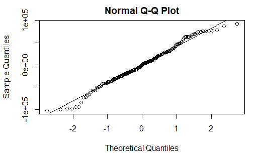

```r
aov_inputlag.pr <- proj(inputlag_anova$aov)
inputlag_res <- aov_inputlag.pr[[3]][, "Residuals"]
qqnorm(inputlag_res); qqline(inputlag_res)
```

Run Shapiro-Wilk test

```r
shapiro.test(x = inputlag_res )
```

```
    Shapiro-Wilk normality test

data:  inputlag_res
W = 0.98742, p-value = 0.1459
```

Run Levene test for homogeneity of variance across groups

```r
leveneTest(df_list_md$list_input_lags~df_list_md$group)
```

```
Levene's Test for Homogeneity of Variance (center = median)
       Df F value Pr(>F)
group   2   0.843 0.4323
      162
```

QQplot of the residuals and Shapiro-Wilk test indicates that the assumptions of normal distribution/variance homogenity are met

Boxplot and interaction plot for list input lag by group

```
`fun.y` is deprecated. Use `fun` instead.
```

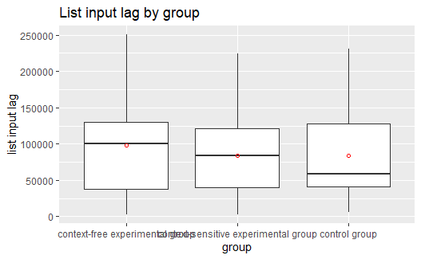

```r
ggplot(df_list_md,aes(x = group, y=list_input_lags) ) +
  geom_boxplot() +
  stat_summary(fun.y=mean,shape=1,col='red',geom='point') +
  labs(x="group",
       y = "list input lag",
       title="List input lag by group")
```

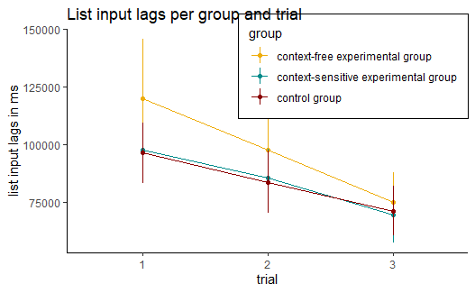

```r
df_list_md %>%
  group_by(trial,group) %>%
  summarise(lil_groups = mean(list_input_lags),
            lil_sem = (sd(list_input_lags)/sqrt(length(list_input_lags)))) -> df_lil
plot_lil = df_lil %>%
  ggplot() +
  aes(x = trial, y = lil_groups, colour = group) +
  theme_classic() +
  geom_line(aes(group = group)) +
  scale_color_manual(values =  c('darkgoldenrod2', 'darkcyan', 'darkred')) +
  geom_point() +
  geom_linerange(aes(x = trial, ymin = lil_groups - lil_sem, ymax = lil_groups + lil_sem), size = .3) +
  theme(legend.justification=c(1,0), legend.position=c(1,0.6), legend.box.background = element_rect(),
  legend.box.margin = margin(4, 4, 4, 4)) +
  labs(title = "List input lags per group and trial", y = "list input lags in ms")
plot_lil
ggsave("plots_hypothesis_tests/list_input_lags_per_groups.png", height = 5, width = 7)
```

Post-hoc tests

```r
pwc_trial <- df_list_md %>%
  pairwise_t_test(
    list_input_lags ~ trial, paired = TRUE,
    p.adjust.method = "holm"
    )
pwc_trial
```

|  | .y. | group1 | group2 | n1 | n2 | statistic | df | p | p.adj | p.adj.signif |
| --- | --- | --- | --- | --- | --- | --- | --- | --- | --- | --- |
| 1 | list_input_lags | 1 | 2 | 55 | 55 | 1.571422 | 54 | 0.122 | 0.214 | ns |
| 2 | list_input_lags | 1 | 3 | 55 | 55 | 2.893041 | 54 | 0.005 | 0.016 | * |
| 3 | list_input_lags | 2 | 3 | 55 | 55 | 1.638939 | 54 | 0.107 | 0.214 | ns |

### Purposeful action lags

Analyse differences between experimental groups in the time it takes them until the next purposeful action. There are no advantages of log-transforming or inverting the purposeful action lags in terms of the normal distribution chracteristics of the data. Therefore, the analysis of the untransformed values shall be reported.

Create dataframe without control group

```r
df_exp <- df_long[!(df_long$group=="control group"),]
```

Convert group and trial to factors

```r
df_exp$group <- factor(df_exp$group)
df_exp$trial <- factor(df_exp$trial)
```

Substitute missing values with group median

```r
df_exp <- df_exp  %>% select(partnr, trial, group, purposeful_action_lags)
list_exp1 <- df_exp$purposeful_action_lags[which(df_exp$group == "context-sensitive experimental group")]
list_exp2 <- df_exp$purposeful_action_lags[which(df_exp$group == "context-free experimental group")]
md_exp1 <- median(list_exp1, na.rm = TRUE)
md_exp2 <- median(list_exp2, na.rm = TRUE)
# replace NA's with median
df_exp$purposeful_action_lags[is.na(df_exp$purposeful_action_lags) & df_exp$group == "context-sensitive experimental group"] <- md_exp1
df_exp$purposeful_action_lags[is.na(df_exp$purposeful_action_lags) & df_exp$group == "context-free experimental group"] <- md_exp2
## check NA's
## missing values per group
aggregate(df_exp$purposeful_action_lags, by= list(df_exp$group),FUN=function(x) {sum(is.na(x))} )
```

| Group.1 | x |
| --- | --- |
| context-free experimental group | 0 |
| context-sensitive experimental group | 0 |

##### Plot the interaction

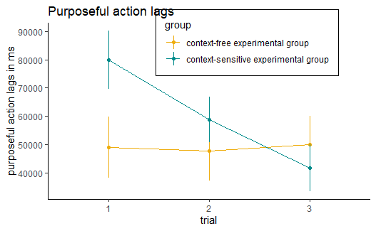

```r
df_exp %>%
  group_by(trial,group) %>%
  summarise(ppa_groups = mean(purposeful_action_lags),
            ppa_sem = (sd(purposeful_action_lags)/sqrt(length(purposeful_action_lags)))) -> df_ppa
plot_ppa = df_ppa %>%
  ggplot() +
  theme_classic() +
  aes(x = trial, y = ppa_groups, colour = group) +
  geom_line(aes(group = group)) +
  scale_color_manual(values =  c('darkgoldenrod2', 'darkcyan', 'darkred')) +
  geom_point() +
  geom_linerange(aes(x = trial, ymin = ppa_groups - ppa_sem, ymax = ppa_groups + ppa_sem), size = .3) +
  theme(legend.justification=c(1,0), legend.position = c(0.9, 0.7), legend.box.background = element_rect(),
  legend.box.margin = margin(4,4,4,4))+
  labs(title = "Purposeful action lags", y = "purposeful action lags in ms")
plot_ppa
ggsave("plots_hypothesis_tests/ppa_per_groups.png", height = 5, width=7)
```

##### Boxplot for purposeful action lag by group

```
`fun.y` is deprecated. Use `fun` instead.
```

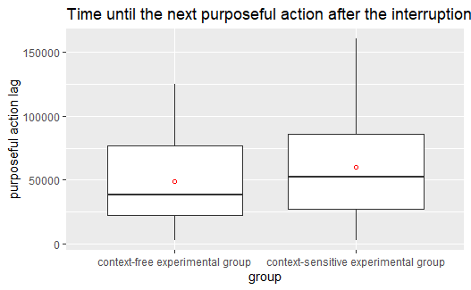

```r
ggplot(df_exp,aes(x = group, y=purposeful_action_lags) ) +
  geom_boxplot() +
  stat_summary(fun.y=mean,shape=1,col='red',geom='point') +
  labs(x="group",
       y = "purposeful action lag",
       title="Time until the next purposeful action after the interruption (in ms)")
```

##### Compute ezANOVA to extract residuals

```r
purposeful_action_lag_anova = ezANOVA(
data = df_exp
, dv = purposeful_action_lags
, wid = partnr
, within = trial
, between = group
, detailed = TRUE
, type = 3
, return_aov = TRUE
)
```

```
You have removed one or more Ss from the analysis. Refactoring "partnr" for ANOVA.Data is unbalanced (unequal N per group). Make sure you specified a well-considered value for the type argument to ezANOVA().
```

```r
anova_out(purposeful_action_lag_anova)
```

```
$`--- ANOVA RESULTS     ------------------------------------`
       Effect        MSE df1 df2      F     p petasq getasq
1 (Intercept) 1660156280   1  32 173.21 0.000   0.84   0.66
2       group 1660156280   1  32   1.80 0.190   0.05   0.02
3       trial 1527322139   2  64   1.83 0.168   0.05   0.04
4 group:trial 1527322139   2  64   1.99 0.145   0.06   0.04

$`--- SPHERICITY TESTS  ------------------------------------`
       Effect p_Mauchly GGEpsilon  p_GG HFEpsilon  p_HF
1       trial     0.481     0.956 0.170     1.015 0.168
2 group:trial     0.481     0.956 0.147     1.015 0.145

$`--- FORMATTED RESULTS ------------------------------------`
       Effect                                   Text
1 (Intercept) F(1, 32) = 173.21, p < .001, np2 = .84
2       group F(1, 32) =   1.80, p = .190, np2 = .05
3       trial F(2, 64) =   1.83, p = .168, np2 = .05
4 group:trial F(2, 64) =   1.99, p = .145, np2 = .06

$`NOTE:`
[1] "No adjustments necessary (all p_Mauchly > 0.05)."
```

Check normal distribution assumption by plotting residuals

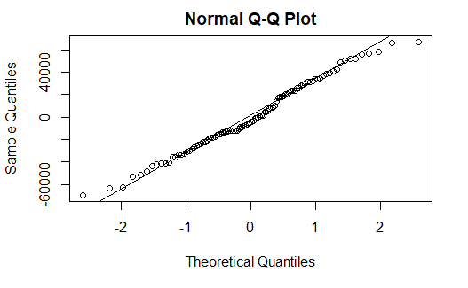

```r
aov_ppa.pr <- proj(purposeful_action_lag_anova$aov)
ppa_res <- aov_ppa.pr[[3]][, "Residuals"]
qqnorm(ppa_res); qqline(ppa_res)
```

Run Shapiro-Wilk test

```r
shapiro.test(df_exp$purposeful_action_lags)
```

```
    Shapiro-Wilk normality test

data:  df_exp$purposeful_action_lags
W = 0.93166, p-value = 5.234e-05
```

Run Levene test for homogenity of variance across groups

```r
leveneTest(df_exp$purposeful_action_lags~df_exp$group)
```

```
Levene's Test for Homogeneity of Variance (center = median)
       Df F value Pr(>F)
group   1  1.7892 0.1841
      100
```

QQplot of the residuals and the Shapiro-Wilk test indicate that the assumptions of normal distribution is not met.

#### Compute robust ANOVA

```r
bwtrim(formula = purposeful_action_lags ~ group * trial, id = partnr, data = df_exp)
```

```
Call:
bwtrim(formula = purposeful_action_lags ~ group * trial, id = partnr,
    data = df_exp)
```

|  | value | df1 | df2 | p.value |
| --- | --- | --- | --- | --- |
| group | 1.7202 | 1 | 15.9871 | 0.2082 |
| trial | 1.8436 | 2 | 13.9046 | 0.1949 |
| group:trial | 2.5798 | 2 | 13.9046 | 0.1115 |

```
NA
```